# Dictionaries

2020 November

A new packages to install: `devtools` and `quanteda.dictionaries` and `quanteda.corpora`

```r
install.packages("devtools")
devtools::install_github("kbenoit/quanteda.dictionaries") # press 3, so no package are updated during install
devtools::install_github("quanteda/quanteda.corpora") # press 3, so no package are updated during install
install.packages("tibble")
install.packages("broom")
```

And the packages that we’ll use.

```r
library(dplyr)
library(lubridate)
library(stringr)
library(ggplot2)
library(quanteda)
library(quanteda.corpora)
library(quanteda.dictionaries)
library(broom)


set.seed(042)
```

# 1 dictionaries in quanteda

We can create dictionaries in `quanteda` with the `dictionary()` function. They are essentially named lists of words combined into a single object. The function allows to load a file from your computer or create one in R.

We’ll use the Laver-Garry dictionary which is in the /dictionary folder and load it into R. If it is in a specific dictionary format, you can specify it in the `format =` argument.

```r
lg_dict <- dictionary(file = "dictionary/laver-garry.cat")
```

The Laver-Garry is a hierarchical dictionary with many subcategories. We can use the `summary()` and `str()` function to get a better sense of our dictionary object. The summary only displays the topmost levels.

```r
summary(lg_dict)
```

```
#>               Length Class       Mode
#> CULTURE        3     dictionary2 list
#> ECONOMY        3     dictionary2 list
#> ENVIRONMENT    2     dictionary2 list
#> GROUPS         2     dictionary2 list
#> INSTITUTIONS   3     dictionary2 list
#> LAW_AND_ORDER  2     dictionary2 list
#> RURAL         16     -none-      character
#> URBAN          1     -none-      character
#> VALUES         2     dictionary2 list
```

With str we can see the whole structure of the object.

```r
str(lg_dict)
```

```
#> Formal class 'dictionary2' [package "quanteda"] with 2 slots
#>   ..@ .Data:List of 9
#>   .. ..$ :List of 4
#>   .. .. ..$ CULTURE-HIGH   :List of 1
#>   .. .. .. ..$ : chr [1:8] "art" "artistic" "dance" "galler*" ...
#>   .. .. ..$ CULTURE-POPULAR:List of 1
#>   .. .. .. ..$ : chr "media"
#>   .. .. ..$ SPORT          :List of 1
#>   .. .. .. ..$ : chr "angler*"
#>   .. .. ..$                : chr [1:3] "people" "war_in_iraq" "civil_war"
#>   .. ..$ :List of 3
#>   .. .. ..$ +STATE+:List of 1
#>   .. .. .. ..$ : chr [1:50] "accommodation" "age" "ambulance" "assist" ...
#>   .. .. ..$ =STATE=:List of 1
#>   .. .. .. ..$ : chr [1:71] "accountant" "accounting" "accounts" "advert*" ...
#>   .. .. ..$ -STATE-:List of 1
#>   .. .. .. ..$ : chr [1:62] "assets" "autonomy" "barrier*" "bid" ...
#>   .. ..$ :List of 2
#>   .. .. ..$ CON ENVIRONMENT:List of 1
#>   .. .. .. ..$ : chr "produc*"
#>   .. .. ..$ PRO ENVIRONMENT:List of 1
#>   .. .. .. ..$ : chr [1:28] "car" "catalytic" "chemical*" "chimney*" ...
#>   .. ..$ :List of 2
#>   .. .. ..$ ETHNIC:List of 1
#>   .. .. .. ..$ : chr [1:5] "asian*" "buddhist*" "ethnic*" "race" ...
#>   .. .. ..$ WOMEN :List of 1
#>   .. .. .. ..$ : chr [1:3] "girls" "woman" "women"
#>   .. ..$ :List of 3
#>   .. .. ..$ CONSERVATIVE:List of 1
#>   .. .. .. ..$ : chr [1:11] "authority" "continu*" "disrupt*" "inspect*" ...
#>   .. .. ..$ NEUTRAL     :List of 1
#>   .. .. .. ..$ : chr [1:38] "administr*" "advis*" "agenc*" "amalgamat*" ...
#>   .. .. ..$ RADICAL     :List of 1
#>   .. .. .. ..$ : chr [1:23] "abolition" "accountable" "answerable" "consult*" ...
#>   .. ..$ :List of 2
#>   .. .. ..$ LAW-CONSERVATIVE:List of 1
#>   .. .. .. ..$ : chr [1:52] "assaults" "bail" "burglar*" "constab*" ...
#>   .. .. ..$ LAW-LIBERAL     :List of 1
#>   .. .. .. ..$ : chr [1:2] "harassment" "non-custodial"
#>   .. ..$ :List of 1
#>   .. .. ..$ : chr [1:16] "agricultur*" "badgers" "bird*" "countryside" ...
#>   .. ..$ :List of 1
#>   .. .. ..$ : chr "town*"
#>   .. ..$ :List of 2
#>   .. .. ..$ CONSERVATIVE:List of 1
#>   .. .. .. ..$ : chr [1:32] "defend" "defended" "defending" "discipline" ...
#>   .. .. ..$ LIBERAL     :List of 1
#>   .. .. .. ..$ : chr [1:10] "cruel*" "discriminat*" "human*" "injustice*" ...
#>   ..@ meta :List of 3
#>   .. ..$ system:List of 5
#>   .. .. ..$ package-version:Classes 'package_version', 'numeric_version'  hidden list of 1
#>   .. .. .. ..$ : int [1:3] 2 1 2
#>   .. .. ..$ r-version      :Classes 'R_system_version', 'package_version', 'numeric_version'  hidden list of 1
#>   .. .. .. ..$ : int [1:3] 4 0 3
#>   .. .. ..$ system         : Named chr [1:3] "Windows" "x86-64" "Akos"
#>   .. .. .. ..- attr(*, "names")= chr [1:3] "sysname" "machine" "user"
#>   .. .. ..$ directory      : chr "E:/Dropbox/teaching/poltext/text_mining_workshop/04_dictionary"
#>   .. .. ..$ created        : Date[1:1], format: "2020-11-25"
#>   .. ..$ object:List of 2
#>   .. .. ..$ valuetype: chr "glob"
#>   .. .. ..$ separator: chr " "
#>   .. ..$ user  : list()
```

Let’s dig around a bit.

```r
sample(lg_dict$ECONOMY$`+STATE+`, 5)
```

```
#> [1] "vulnerable"    "pension"       "accommodation" "hardship"
#> [5] "classes"
```

```r
sample(lg_dict$LAW_AND_ORDER$`LAW-CONSERVATIVE`, 5)
```

```
#> [1] "punish*"     "force*"      "unlawful"    "trafficker*" "joy-ride*"
```

# 2 LSD on british party manifesto

Load the UK election manifestos corpus from the data/ folder, or from the `quanteda.corpora` package.

```r
load("data/data_corpus_ukmanifestos.rda")

summary(data_corpus_ukmanifestos)
```

```
#> Corpus consisting of 101 documents, showing 100 documents:
#>
#>                    Text Types Tokens Sentences Country Type Year Language
#>     UK_natl_1945_en_Con  1752   6679       269      UK natl 1945       en
#>     UK_natl_1945_en_Lab  1433   5492       234      UK natl 1945       en
#>     UK_natl_1945_en_Lib  1208   3729       157      UK natl 1945       en
#>     UK_natl_1950_en_Con  2075   8075       366      UK natl 1950       en
#>     UK_natl_1950_en_Lab  1541   5392       274      UK natl 1950       en
#>     UK_natl_1950_en_Lib  1202   3322       136      UK natl 1950       en
#>     UK_natl_1951_en_Con  1006   2892       140      UK natl 1951       en
#>     UK_natl_1951_en_Lab   736   1996       117      UK natl 1951       en
#>     UK_natl_1951_en_Lib   816   2286       103      UK natl 1951       en
#>     UK_natl_1955_en_Con  2632  12944       608      UK natl 1955       en
#>     UK_natl_1955_en_Lab  1130   3183       146      UK natl 1955       en
#>     UK_natl_1959_en_Con  1676   5612       250      UK natl 1959       en
#>     UK_natl_1959_en_Lab  1676   5612       250      UK natl 1959       en
#>     UK_natl_1959_en_Lib   953   2823       139      UK natl 1959       en
#>     UK_natl_1964_en_Con  2246   8807       412      UK natl 1964       en
#>     UK_natl_1964_en_Lab  2493  10776       360      UK natl 1964       en
#>     UK_natl_1964_en_Lib  1422   4547       215      UK natl 1964       en
#>     UK_natl_1966_en_Con  1513   5071       277      UK natl 1966       en
#>     UK_natl_1966_en_Lab  2645  12043       569      UK natl 1966       en
#>     UK_natl_1966_en_Lib  1847   6544       338      UK natl 1966       en
#>     UK_natl_1970_en_Con  2331  11645       547      UK natl 1970       en
#>     UK_natl_1970_en_Lab  2661  13016       529      UK natl 1970       en
#>     UK_natl_1970_en_Lib  1096   3151       184      UK natl 1970       en
#>     UK_natl_1974_en_Con  2817  15562       662      UK natl 1974       en
#>     UK_natl_1974_en_Lab  2205   9588       367      UK natl 1974       en
#>     UK_natl_1974_en_Lib  2515  10145       353      UK natl 1974       en
#>     UK_natl_1979_en_Con  8092  98066      4668      UK natl 1979       en
#>     UK_natl_1979_en_Lab  6956  78274      3621      UK natl 1979       en
#>     UK_natl_1979_en_Lib  2119   7738       336      UK natl 1979       en
#>     UK_natl_1983_en_Con  2774  13258       606      UK natl 1983       en
#>     UK_natl_1983_en_Lab  3682  25455      1114      UK natl 1983       en
#>  UK_natl_1983_en_LibSDP  2893  14570       495      UK natl 1983       en
#>     UK_natl_1987_en_Con  3517  19682       914      UK natl 1987       en
#>     UK_natl_1987_en_Lab  2389  10012       450      UK natl 1987       en
#>  UK_natl_1987_en_LibSDP  3326  21349       636      UK natl 1987       en
#>     UK_natl_1992_en_Con  4676  33116      1585      UK natl 1992       en
#>     UK_natl_1992_en_Lab  2384  12551       562      UK natl 1992       en
```

[output cut: 250 more lines]

```
#>    /Users/kbenoit/Dropbox/QUANTESS/corpora/ukManRenamed/UK_natl_2005_en_OMRL.txt
#>     /Users/kbenoit/Dropbox/QUANTESS/corpora/ukManRenamed/UK_natl_2005_en_PCy.txt
#>      /Users/kbenoit/Dropbox/QUANTESS/corpora/ukManRenamed/UK_natl_2005_en_PP.txt
#>     /Users/kbenoit/Dropbox/QUANTESS/corpora/ukManRenamed/UK_natl_2005_en_PVP.txt
#>    /Users/kbenoit/Dropbox/QUANTESS/corpora/ukManRenamed/UK_natl_2005_en_Resp.txt
#>      /Users/kbenoit/Dropbox/QUANTESS/corpora/ukManRenamed/UK_natl_2005_en_RT.txt
#>    /Users/kbenoit/Dropbox/QUANTESS/corpora/ukManRenamed/UK_natl_2005_en_SDLP.txt
#>      /Users/kbenoit/Dropbox/QUANTESS/corpora/ukManRenamed/UK_natl_2005_en_SF.txt
#>     /Users/kbenoit/Dropbox/QUANTESS/corpora/ukManRenamed/UK_natl_2005_en_SNP.txt
#>      /Users/kbenoit/Dropbox/QUANTESS/corpora/ukManRenamed/UK_natl_2005_en_SP.txt
#>     /Users/kbenoit/Dropbox/QUANTESS/corpora/ukManRenamed/UK_natl_2005_en_SSP.txt
#>      /Users/kbenoit/Dropbox/QUANTESS/corpora/ukManRenamed/UK_natl_2005_en_TW.txt
#>    /Users/kbenoit/Dropbox/QUANTESS/corpora/ukManRenamed/UK_natl_2005_en_UKIP.txt
#>     /Users/kbenoit/Dropbox/QUANTESS/corpora/ukManRenamed/UK_natl_2005_en_UUP.txt
#>     /Users/kbenoit/Dropbox/QUANTESS/corpora/ukManRenamed/UK_natl_2005_en_Ver.txt
```

```r
uk_subset <- corpus_subset(data_corpus_ukmanifestos, Year >= 1970 & Year <= 1974)

uk_subset
```

```
#> Corpus consisting of 6 documents and 6 docvars.
#> UK_natl_1970_en_Con :
#> "CONSERVATIVE PARTY: 1970  A Better Tomorrow FOREWORD  This M..."
#>
#> UK_natl_1970_en_Lab :
#> "Labour Party: 1970  NOW BRITAIN'S STRONG - LET'S MAKE IT GRE..."
#>
#> UK_natl_1970_en_Lib :
#> "LIBERAL PARTY: 1970  What a Life! There must surely be a bet..."
#>
#> UK_natl_1974_en_Con :
#> "Conservative Manifesto: October 1974  Putting Britain First ..."
#>
#> UK_natl_1974_en_Lab :
#> "The Labour Party Manifesto: October, 1974  BRITAIN WILL WIN ..."
#>
#> UK_natl_1974_en_Lib :
#> "The Liberal Party:  'Change the face of Britain' THE CRISIS ..."
```

We know that we want to use the Lexicoder dictionary to estimate the positive or negative sentiments in these party manifestos. It is part of quanteda, as `data_dictionary_LSD2015`. Let’s look around.

```r
dict_lsd <- data_dictionary_LSD2015

summary(dict_lsd)
```

```
#>              Length Class  Mode
#> negative     2858   -none- character
#> positive     1709   -none- character
#> neg_positive 1721   -none- character
#> neg_negative 2860   -none- character
```

```r
str(dict_lsd)
```

```
#> Formal class 'dictionary2' [package "quanteda"] with 2 slots
#>   ..@ .Data:List of 4
#>   .. ..$ :List of 1
#>   .. .. ..$ : chr [1:2858] "a lie" "abandon*" "abas*" "abattoir*" ...
#>   .. ..$ :List of 1
#>   .. .. ..$ : chr [1:1709] "ability*" "abound*" "absolv*" "absorbent*" ...
#>   .. ..$ :List of 1
#>   .. .. ..$ : chr [1:1721] "best not" "better not" "no damag*" "no no" ...
#>   .. ..$ :List of 1
#>   .. .. ..$ : chr [1:2860] "not a lie" "not abandon*" "not abas*" "not abattoir*" ...
#>   ..@ meta :List of 3
#>   .. ..$ system:List of 5
#>   .. .. ..$ package-version:Classes 'package_version', 'numeric_version'  hidden list of 1
#>   .. .. .. ..$ : int [1:3] 1 9 9009
#>   .. .. ..$ r-version      :Classes 'R_system_version', 'package_version', 'numeric_version'  hidden list of 1
#>   .. .. .. ..$ : int [1:3] 3 6 2
#>   .. .. ..$ system         : Named chr [1:3] "Darwin" "x86_64" "kbenoit"
#>   .. .. .. ..- attr(*, "names")= chr [1:3] "sysname" "machine" "user"
#>   .. .. ..$ directory      : chr "/Users/kbenoit/Dropbox (Personal)/GitHub/quanteda/quanteda"
#>   .. .. ..$ created        : Date[1:1], format: "2020-02-17"
#>   .. ..$ object:List of 2
#>   .. .. ..$ valuetype: chr "glob"
#>   .. .. ..$ separator: chr " "
#>   .. ..$ user  :List of 6
#>   .. .. ..$ title      : chr "Lexicoder Sentiment Dictionary (2015)"
#>   .. .. ..$ description: chr "The 2015 Lexicoder Sentiment Dictionary in quanteda dictionary format.  \n\nThe dictionary consists of 2,858 \""| __truncated__
#>   .. .. ..$ source     : chr "Young, L. & Soroka, S. (2012). Affective News: The Automated Coding of Sentiment in Political Texts. Political "| __truncated__
#>   .. .. ..$ url        : chr "http://lexicoder.com"
#>   .. .. ..$ license    : chr "The LSD is available for non-commercial academic purposes only. By using data_dictionary_LSD2015, you accept th"| __truncated__
#>   .. .. ..$ keywords   : chr [1:4] "political" "news" "sentiment" "media"
```

```r
sample(dict_lsd$negative, 10)
```

```
#>  [1] "browbeaten*" "ludicrous*"  "balk"        "unlikely"    "subver*"
#>  [6] "paralyze*"   "doleful*"    "critiqu*"    "helpless*"   "drowsy*"
```

```r
sample(dict_lsd$positive, 10)
```

```
#>  [1] "marvel*"       "fondness"      "tenderness"    "reconcil*"
#>  [5] "impresses"     "cheery*"       "sanitary*"     "dispensatory*"
#>  [9] "safety*"       "accurat*"
```

```r
sample(dict_lsd$neg_positive, 10)
```

```
#>  [1] "not precis*"    "not coaction*"  "not correcting" "not comfort"
#>  [5] "not warmed"     "not righted"    "not humored*"   "not loyal*"
#>  [9] "not attain*"    "not valour*"
```

What decisions should we make when we create our document-feature matrix?

```r
uk_dfm <- dfm(uk_subset, tolower = TRUE, remove_punct = TRUE, remove = stopwords("en"))
```

To apply the dictionary, we use the `dictionary` argument of the `dfm` function.

```r
uk_sentiment <- dfm(uk_dfm, dictionary = dict_lsd)

uk_sentiment
```

```
#> Document-feature matrix of: 6 documents, 4 features (50.0% sparse) and 6 docvars.
#>                      features
#> docs                  negative positive neg_positive neg_negative
#>   UK_natl_1970_en_Con      349      782            0            0
#>   UK_natl_1970_en_Lab      330      698            0            0
#>   UK_natl_1970_en_Lib       85      177            0            0
#>   UK_natl_1974_en_Con      437      899            0            0
#>   UK_natl_1974_en_Lab      273      500            0            0
#>   UK_natl_1974_en_Lib      350      495            0            0
```

Let’s add the net sentiment to the docvars of our corpus. We should also create a net sentiment from the positive and negative categories.

```r
docvars(uk_subset, "net_sentiment") <- as.numeric(uk_sentiment[, 2]) - as.numeric(uk_sentiment[, 1])

docvars(uk_subset)
```

```
#>   Country Type Year Language Party
#> 1      UK natl 1970       en   Con
#> 2      UK natl 1970       en   Lab
#> 3      UK natl 1970       en   Lib
#> 4      UK natl 1974       en   Con
#> 5      UK natl 1974       en   Lab
#> 6      UK natl 1974       en   Lib
#>                                                                        _source
#> 1 /Users/kbenoit/Dropbox/QUANTESS/corpora/ukManRenamed/UK_natl_1970_en_Con.txt
#> 2 /Users/kbenoit/Dropbox/QUANTESS/corpora/ukManRenamed/UK_natl_1970_en_Lab.txt
#> 3 /Users/kbenoit/Dropbox/QUANTESS/corpora/ukManRenamed/UK_natl_1970_en_Lib.txt
#> 4 /Users/kbenoit/Dropbox/QUANTESS/corpora/ukManRenamed/UK_natl_1974_en_Con.txt
#> 5 /Users/kbenoit/Dropbox/QUANTESS/corpora/ukManRenamed/UK_natl_1974_en_Lab.txt
#> 6 /Users/kbenoit/Dropbox/QUANTESS/corpora/ukManRenamed/UK_natl_1974_en_Lib.txt
#>   net_sentiment
#> 1           433
#> 2           368
#> 3            92
#> 4           462
#> 5           227
#> 6           145
```

Time to plot! First we create a data frame from our corpus variables.

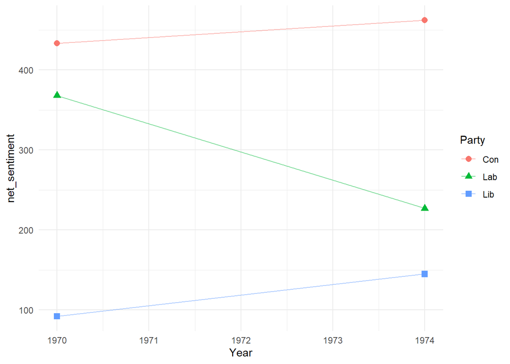

```r
uk_df <- as.data.frame(docvars(uk_subset)) %>%
    tibble::rownames_to_column("text")

ggplot(data = uk_df, mapping = aes(x = Year, y = net_sentiment, color = Party)) +
    geom_point(aes(shape = Party), size = 2.5) +
    geom_line(alpha = 0.5) +
    theme_minimal()
```

Did we miss anything? What are some additional steps that we would do in a real analysis?

# 3 NRC on Tweets

As the next demonstration we will use another type of dictionary on a different type of corpus. The NRC Word-Emotion Association Lexicon comes from the `quanteda.dictionaries` package, and the corpus is either loaded from the `data/` folder or from the `quanteda.corpora` package.

```r
nrc_dict <- quanteda.dictionaries::data_dictionary_NRC

summary(nrc_dict)
```

```
#>              Length Class  Mode
#> anger        1247   -none- character
#> anticipation  839   -none- character
#> disgust      1058   -none- character
#> fear         1476   -none- character
#> joy           689   -none- character
#> negative     3324   -none- character
#> positive     2312   -none- character
#> sadness      1191   -none- character
#> surprise      534   -none- character
#> trust        1231   -none- character
```

The corpus we use is Trump tweets in the 2016 election campaign. An interesting analysis (where the data is coming from) is here from David Robinson: http://varianceexplained.org/r/trump-tweets/. We’ll replicate some of that work with quanteda.

```r
load("data/trump_tweets.Rda")

glimpse(trump_tweets_df)
```

```
#> Rows: 1,512
#> Columns: 16
#> $ text          <chr> "My economic policy speech will be carried live at 12...
#> $ favorited     <lgl> FALSE, FALSE, FALSE, FALSE, FALSE, FALSE, FALSE, FALS...
#> $ favoriteCount <dbl> 9214, 6981, 15724, 19837, 34051, 29831, 19223, 19543,...
#> $ replyToSN     <chr> NA, NA, NA, NA, NA, NA, NA, NA, NA, NA, NA, NA, NA, N...
#> $ created       <dttm> 2016-08-08 15:20:44, 2016-08-08 13:28:20, 2016-08-08...
#> $ truncated     <lgl> FALSE, FALSE, FALSE, FALSE, FALSE, FALSE, FALSE, FALS...
#> $ replyToSID    <lgl> NA, NA, NA, NA, NA, NA, NA, NA, NA, NA, NA, NA, NA, N...
#> $ id            <chr> "762669882571980801", "762641595439190016", "76243965...
#> $ replyToUID    <chr> NA, NA, NA, NA, NA, NA, NA, NA, NA, NA, NA, NA, NA, N...
#> $ statusSource  <chr> "<a href=\"http://twitter.com/download/android\" rel=...
#> $ screenName    <chr> "realDonaldTrump", "realDonaldTrump", "realDonaldTrum...
#> $ retweetCount  <dbl> 3107, 2390, 6691, 6402, 11717, 9892, 5784, 7930, 2466...
#> $ isRetweet     <lgl> FALSE, FALSE, FALSE, FALSE, FALSE, FALSE, FALSE, FALS...
#> $ retweeted     <lgl> FALSE, FALSE, FALSE, FALSE, FALSE, FALSE, FALSE, FALS...
#> $ longitude     <chr> NA, NA, NA, NA, NA, NA, NA, NA, NA, NA, NA, NA, NA, N...
#> $ latitude      <chr> NA, NA, NA, NA, NA, NA, NA, NA, NA, NA, NA, NA, NA, N...
```

Let’s make some adjustments to our data. We want to extract the device the tweet is made and only keep some relevant variables.

```r
trump_tweets_df <- trump_tweets_df %>%
    mutate(device = str_extract(statusSource, "android|iphone")) %>%
    filter(isRetweet == FALSE, device %in% c("android", "iphone")) %>%
    select(text, device, created, favoriteCount, retweetCount)
```

```r
trump_corpus <- corpus(trump_tweets_df)
```

Let’s apply our dictionary, but now with the `dfm_lookup` function.

```r
trump_sentiment <- trump_corpus %>%
    dfm() %>%
    dfm_lookup(dictionary = nrc_dict)

head(trump_sentiment, 15)
```

```
#> Document-feature matrix of: 15 documents, 10 features (68.7% sparse) and 4 docvars.
#>        features
#> docs    anger anticipation disgust fear joy negative positive sadness surprise
#>   text1     0            1       0    0   1        0        2       0        0
#>   text2     0            1       0    0   0        0        1       0        0
#>   text3     0            0       0    0   0        0        1       1        1
#>   text4     1            1       1    1   0        2        1       1        0
#>   text5     2            0       1    1   1        2        1       2        0
#>   text6     0            0       0    0   0        1        2       0        0
#>        features
#> docs    trust
#>   text1     2
#>   text2     0
#>   text3     1
#>   text4     2
#>   text5     0
#>   text6     0
#> [ reached max_ndoc ... 9 more documents ]
```

we add the sentiment scores back to our original dataset.

```r
trump_sentiment_df <- convert(trump_sentiment, to = "data.frame")

trump_tweets_df <- bind_cols(trump_tweets_df, trump_sentiment_df)
```

Some plots to satisfy our curiosity

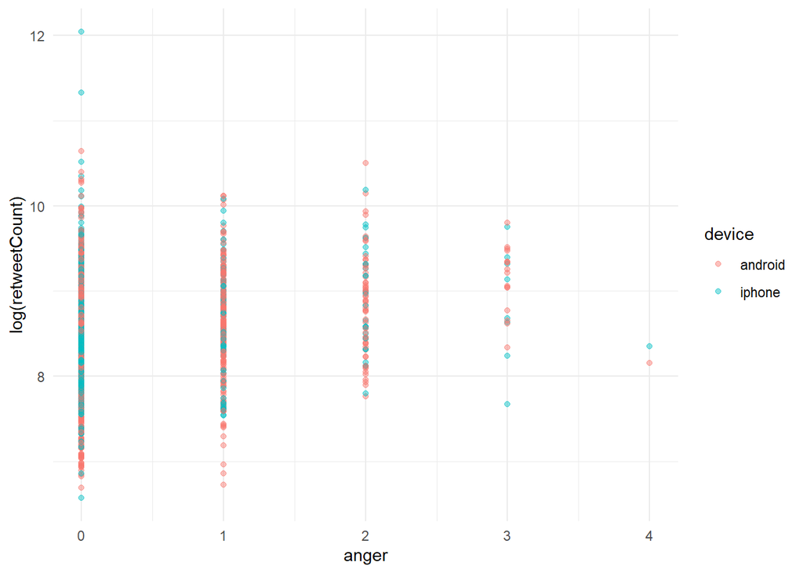

```r
ggplot(trump_tweets_df, aes(x = anger, y = log(retweetCount), color = device)) +
    geom_point(alpha = 0.45) +
    theme_minimal()
```

```r
summary(lm(log(retweetCount) ~ anger + fear + joy + negative + positive + sadness + surprise + trust + factor(device), data = trump_tweets_df))
```

```
#>
#> Call:
#> lm(formula = log(retweetCount) ~ anger + fear + joy + negative +
#>     positive + sadness + surprise + trust + factor(device), data = trump_tweets_df)
#>
#> Residuals:
#>     Min      1Q  Median      3Q     Max
#> -2.0892 -0.4347 -0.0081  0.4159  3.5490
#>
#> Coefficients:
#>                       Estimate Std. Error t value Pr(>|t|)
#> (Intercept)           8.337912   0.033336 250.114  < 2e-16 ***
#> anger                -0.002952   0.041074  -0.072 0.942715
#> fear                  0.169597   0.036406   4.658 3.49e-06 ***
#> joy                  -0.096870   0.038588  -2.510 0.012174 *
#> negative              0.116316   0.031753   3.663 0.000259 ***
#> positive              0.010661   0.023968   0.445 0.656542
#> sadness              -0.057231   0.042555  -1.345 0.178886
#> surprise             -0.093099   0.034935  -2.665 0.007790 **
#> trust                 0.117524   0.028227   4.163 3.33e-05 ***
#> factor(device)iphone  0.153878   0.035580   4.325 1.64e-05 ***
#> ---
#> Signif. codes:  0 '***' 0.001 '**' 0.01 '*' 0.05 '.' 0.1 ' ' 1
#>
#> Residual standard error: 0.63 on 1380 degrees of freedom
#> Multiple R-squared:  0.09526,    Adjusted R-squared:  0.08936
#> F-statistic: 16.14 on 9 and 1380 DF,  p-value: < 2.2e-16
```

Visualize our results

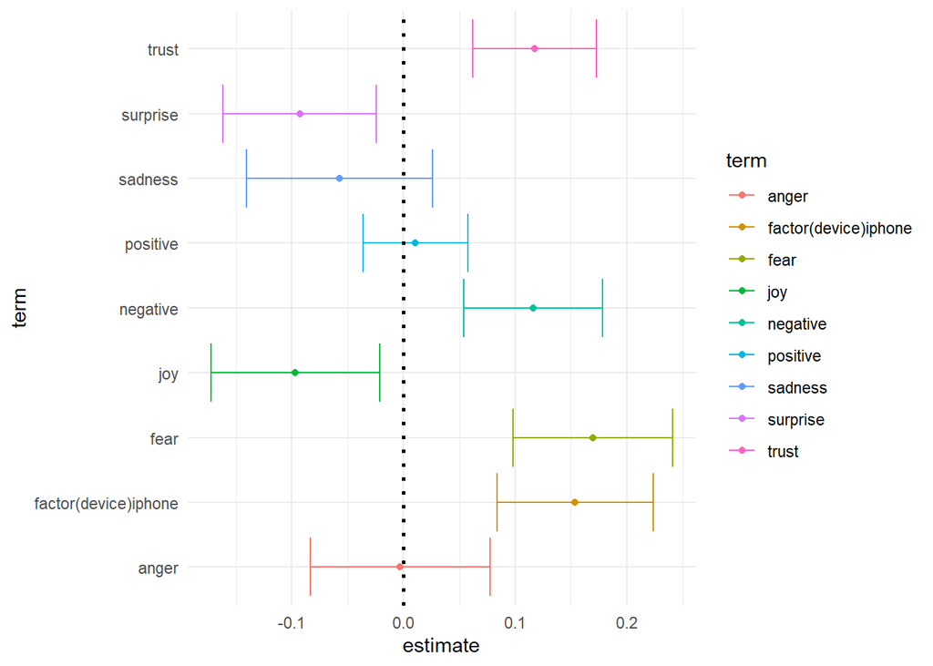

```r
ols <- lm(log(retweetCount) ~ anger + fear + joy + negative + positive + sadness + surprise + trust + factor(device), data = trump_tweets_df)

ols_coef <- tidy(ols, conf.int = TRUE)

ggplot(ols_coef[2:10,], aes(estimate, term, color = term)) +
    geom_point()+
    geom_errorbarh(aes(xmin = conf.low, xmax = conf.high)) +
    geom_vline(xintercept = 0, size = 1, linetype = "dotted") +
    theme_minimal()
```

# 4 Create dictionary

As quick excercise we’ll create a dictionary for Trump tweets. For inspiration: https://www.nytimes.com/interactive/2016/01/28/upshot/donald-trump-twitter-insults.html

```r
dict_trump <- dictionary(list(insult = c("crooked", "fake", "crazy", "failing", "wrong", "phony"),
                              happy = c("great", "proud", "deal", "approval")))

trump_insult <- trump_corpus %>%
    dfm() %>%
    dfm_lookup(dictionary = dict_trump)

head(trump_insult)
```

```
#> Document-feature matrix of: 6 documents, 2 features (83.3% sparse) and 4 docvars.
#>        features
#> docs    insult happy
#>   text1      0     0
#>   text2      0     0
#>   text3      0     0
#>   text4      0     0
#>   text5      1     0
#>   text6      1     0
```